# 6.2: Production model runs: Seabream

FAO Climate Change Risks to Fed Mariculture

Author

Tormey Reimer

Published

10 June 2026

← Previous: Extracting future temperatures

Next: Home →

# Overview

This document runs the production for the `seabream` model.

# Species and feed parameters

**Load species parameters for seabream**

```r
species_params <- file.path(prepdata_path, "species_parameters", "species_parameters_seabream.qs") %>%
  qd_read()
```

**Load feed and ingredient data and calculate feed composition parameters**

```r
feeds_df <- read_excel(here("data", "raw_data", "feed_profiles_and_composition.xlsx"), sheet = "all_feeds") %>%
  select(feed, ingredient, proportion) %>%
  filter(feed == "Gilthead seabream 1")

ingredients_df <- read_excel(here("data", "raw_data", "all_ingredients.xlsx"), sheet = "all_ingredients") %>%
  select(ingredient, protein, lipid, carb)

digestibility_df <- read_excel(here("data", "raw_data", "all_ingredients.xlsx"), sheet = "all_ingredients") %>%
  select(ingredient, mean_protein_digestibility, mean_lipid_digestibility, mean_carb_digestibility) %>%
  rename(
    protein_digestibility = mean_protein_digestibility,
    lipid_digestibility = mean_lipid_digestibility,
    carb_digestibility = mean_carb_digestibility
  )

feed_params <- sum_feeds(
  format_feeds(feeds_df, ingredients_df, digestibility_df)
  )[[1]]
```

# Temperatures

**Load temperatures for all farms assigned for seabram**

```r
farm_temps <- qs2::qs_read(file.path(prepdata_path, "farm_temps_bymodel", "farm_temps_seabream.qs")) %>%
  sf::st_drop_geometry()
farm_temps <- split(farm_temps, farm_temps$farm_ID)
```

# Species production

Per-farm production has been set in the data based on current FAO production statistics. We are going to upscale the individual bioenergetic model to each farm by setting a per-farm population (based in 2025), accounting for expected per-annum mortality.

**Set the grow-times for the species - essentially, the times where it will be most optimal at each farm**

```r
grow_days <- round(species_params[["gd"]], 0)

# ft <- farm_temps[[62]]
farm_temps <- farm_temps %>%
  map(function(ft) {
    # Isolate the temperatures at this farm
    temp <- ft %>%
      sf::st_drop_geometry() %>%
      filter(year == 2025) %>%
      mutate(doy = as.integer(format(date, "%j"))) %>%
      select(doy, sst)

    # Repeat year
    temp <- rbind(
      temp,
      temp %>% mutate(doy = doy + 365)
    )

    # Get feeding response at each DOY
    temp$fr <- sapply(
        X = temp$sst,
        FUN = feeding_rate,
        species_params = species_params
      )
    temp$fr[is.na(temp$fr)] <- 0

    # Get the best "growing window" for this species
    gds <- temp %>%
      mutate(
        roll_fr = slide_dbl(fr, sum, .before = 0, .after = grow_days - 1)
      ) %>%
      # Remove windows that don't have a full 653 days ahead
      slice(1:(n() - grow_days + 1)) %>%
      slice_max(roll_fr, n = 1) %>%
      mutate(end_doy = doy + grow_days - 1)

    ft %>%
      mutate(
        doy_start = gds$doy,
        doy_end = gds$end_doy
      )
  },
  .progress = T
)
```

```
 ■■■■■■■■■■■■                      35% |  ETA:  6s
```

```
 ■■■■■■■■■■■■■■■■■■■■■■■■■         81% |  ETA:  1s
```

**Set the grow-times for the species - essentially, the times where it will be most optimal at each farm**

```r
# Summarise
farm_temps %>%
  bind_rows() %>%
  group_by(country) %>%
  reframe(
    mean_start = mean(doy_start),
    min_start = min(doy_start),
    max_start = max(doy_start),
    mean_end = mean(doy_end),
    min_end = min(doy_end),
    max_end = max(doy_end)
  )
```

```
# A tibble: 32 × 7
   country            mean_start min_start max_start mean_end min_end max_end
   <chr>                   <dbl>     <dbl>     <dbl>    <dbl>   <dbl>   <dbl>
 1 Albania                  97          97        97     730      730     730
 2 Algeria                  93          91        95     726      724     728
 3 Bahrain                   1           1         1     634      634     634
 4 China                    28.4         1        74     661.     634     707
 5 Croatia                  97          97        97     730      730     730
 6 Cyprus                   97          97        97     730      730     730
 7 Dominican Republic        1           1         1     634      634     634
 8 Egypt                    97          97        97     730      730     730
 9 France                   97          97        97     730      730     730
10 Greece                   97          97        97     730      730     730
# ℹ 22 more rows
```

**Assign a population to each farm to acheive expected production (using 2025 temperatures)**

```r
# ft <- farm_temps[[1]]
farm_temps_pops <- farm_temps %>%
  map(function(ft) {
    times <- c(
      t_start = unique(ft$doy_start),
      t_end   = unique(ft$doy_end),
      dt      = 1L
    )
    doys <- seq(times['t_start'], times['t_end'], times['dt'])

    # Filter to actual days in use
    ft_gd <- ft %>%
      sf::st_drop_geometry() %>%
      filter(year == 2025) %>%
      mutate(doy = as.integer(format(date, "%j")))
    ft_gd <- rbind(
      ft_gd,
      ft_gd %>% mutate(doy = doy + 365)
    ) %>%
      filter(doy %in% doys)

    # Get harvest size at this farm
    one_fish <- fish_growth(
      species_params = species_params,
      water_temp     = ft_gd$sst,
      feed_params    = feed_params,
      times          = times,
      init_weight    = species_params["meanW"],    # Use mean stocking weight
      ingmax         = species_params["meanImax"]  # Use mean ingestion coefficient
    ) %>% as.data.frame()

    # IMPORTANT - the number of grow_days is changed here, so that the fish gets as close to CS as possible
    harvest_doy <- one_fish$days[which.min(abs(one_fish$weight - species_params["CS"]))]
    species_params["gd"] <- length(seq(times['t_start'], harvest_doy, times['dt']))       # update species params
    ft$doy_end <- ft$doy_start + species_params["gd"] - 1

    harvest_size <- one_fish$weight[one_fish$days == harvest_doy]
    harvest_t <- unique(ft$prod_perfarm) %>% set_units("t") %>% set_units("g") %>% drop_units()
    ft$harvest_n <- harvest_t/harvest_size
    ft
  },
  .progress = T
)
```

```
 ■■■■■                             14% |  ETA: 18s
```

```
 ■■■■■■■■■■                        29% |  ETA: 15s
```

```
 ■■■■■■■■■■■■■■                    43% |  ETA: 12s
```

```
 ■■■■■■■■■■■■■■■■■■■               58% |  ETA:  9s
```

```
 ■■■■■■■■■■■■■■■■■■■■■■■           74% |  ETA:  5s
```

```
 ■■■■■■■■■■■■■■■■■■■■■■■■■■■       87% |  ETA:  3s
```

## Maintaining consistency through the future

```r
# Pick a subset so it runs faster
farm_IDs_subset <- farm_temps_pops %>%
  bind_rows() %>%
  distinct(ISO3_Code, farm_ID) %>%
  group_by(ISO3_Code) %>%
  slice_sample(n = 1) %>%
  ungroup() %>% pull(farm_ID)

farm_temps_pops <- farm_temps_pops %>%
  bind_rows() %>%
  filter(farm_ID %in% farm_IDs_subset)
farm_temps_pops <- split(farm_temps_pops, farm_temps_pops$farm_ID)
```

If we just run the model now, we are going to run into the problem that warmer temperatures -> smaller fish (especially for salmon, a cold-water species), resulting in lower production. This will confound feed required, as smaller individuals eat less BUT warmer individuals have higher metabolism and eat more. Therefore, we need to explicitly decide on what to change and what to keep constant through time.

*Total harvested biomass = Individual size (after grow days)* Population*

- **Option 1: Let total harvested biomass adapt**. Keep all individual and population parameters fixed through time, and let total harvested biomass change with temperature. While this might be the simplest option to implement/understand, it’s possibly also the least realistic as it assumes that fish farmers will take no adaptive action to prevent their harvests from declining.
- **Option 2: Let fish grow out as needed**. Keep a fixed population and total harvested biomass, and adjust the length of the grow-out period to acheive the required total harvested biomass. On an individual farm level this makes sense (a farmer will just let his stock keep growing until they reach market size), but creates problems from a modelling perspective - fish may never reach market size if temperature changes to much, or a 2-year cohort might become a 3-year cohort (causing problems with reaching the annual production target).
- **Option 3: Let population absorb the difference**. Keep a fixed number of grow-out days, and change farm population to maintain the same total harvested biomass. This possibly makes the most sense, as “population” is an arbitrary calculation used to reach total harvested biomass.

**Run the model with all species and population parameters fixed through time**

```r
# ftp <- farm_temps_pops[[1]]
option_1_changes <- map_dfr(farm_temps_pops, function (ftp) {
  # start_year <- (2025:2098)[1]
  map_dfr(2025:2098, function(start_year) {
    ftpy <- ftp %>%
      filter(year %in% c(start_year, start_year + 1)) %>%
      mutate(
        doy = as.integer(format(date, "%j")),
        doy = case_when(
          year == start_year ~ doy,
          leap_year(date) ~ doy + 366,
          T ~ doy + 365
        )
      ) %>%
      filter(doy >= doy_start)
    ftpy <- ftpy[1:species_params["gd"], ] # required because some years are leap years, so the end date will be a little different
    times <- c(t_start = unique(ftpy$doy_start), t_end = (unique(ftpy$doy_start) + nrow(ftpy) - 1), dt = 1L)

    results_full <- farm_growth_full(
      species_params = species_params,
      feed_params = feed_params,
      water_temp = ftpy$sst,
      times = times,
      use_MC_population = F
    )
    results_consolidate <- consolidate_farm(results_full)
    results_farm <- scale_farm_population(
      consolidated = results_consolidate,
      N_pop = generate_pop(
        harvest_n = unique(ftpy$harvest_n),
        mort = species_params["mortmyt"],
        times = times
      )
    )

    data.frame(
      start_year = start_year,
      individual_weight = last(results_consolidate[["stats"]][["weight"]][,1]),
      farm_biomass = last(results_farm[["stats"]][["weight_scaled"]][,1]),
      farm_food_prov = sum(results_farm[["stats"]][["food_prov_scaled"]][,1], na.rm = T)
    )
  }) %>%
    mutate(
      country = unique(ftp$country),
      farm_ID = unique(ftp$farm_ID)
    )
},
.progress = T
)

qd_save(
  option_1_changes,
  file.path(data_path, "intermediates", "option_1_changes.qs")
)
```

As expected, individual biomass decreases over time due to increasing SST (Figure 1). This results in declining farmed biomass (with the same population) and increasing feed provided per harvested biomass.

**Look at option 1 outcomes**

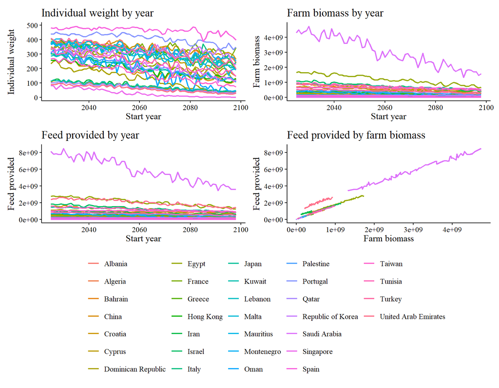

Figure 1: Outputs from Option 1 above - population and species parameters are kept constant through time, so the individual fish weight and harvested biomass are allowed to adapt. Results show a single farm within each country.

```r
option_1_changes <- file.path(data_path, "intermediates", "option_1_changes.qs") %>%
  qd_read() %>%
  mutate(country = as.factor(country))

p1 <- ggplot(option_1_changes, aes(x = start_year, y = individual_weight, colour = country)) +
  geom_line(linewidth = 0.75) +
  labs(x = "Start year", y = "Individual weight", title = "Individual weight by year") +
  prettyplot()

p2 <- ggplot(option_1_changes, aes(x = start_year, y = farm_biomass, colour = country)) +
  geom_line(linewidth = 0.75) +
  labs(x = "Start year", y = "Farm biomass", title = "Farm biomass by year") +
  prettyplot()

p3 <- ggplot(option_1_changes, aes(x = start_year, y = farm_food_prov, colour = country)) +
  geom_line(linewidth = 0.75) +
  labs(x = "Start year", y = "Feed provided", title = "Feed provided by year") +
  prettyplot()

p4 <- ggplot(option_1_changes, aes(x = farm_biomass, y = farm_food_prov, colour = country)) +
  geom_line(linewidth = 0.75) +
  labs(x = "Farm biomass", y = "Feed provided", title = "Feed provided by farm biomass") +
  prettyplot()

(p1 + p2) / (p3 + p4) +
  plot_layout(guides = "collect") &
  theme(legend.position = "bottom")
```

**Run the model with all species and population parameters fixed through time, except for the growout period which changes to adapt with the climate**

```r
# ftp <- farm_temps_pops[[1]]
option_2_changes <- map_dfr(farm_temps_pops, function (ftp) {
  # start_year <- (2025:2098)[1]
  map_dfr(2025:2097, function(start_year) {
    ftpy <- ftp %>%
      filter(year %in% c(start_year, start_year + 1, start_year + 2)) %>%
      mutate(
        doy = as.integer(format(date, "%j")),
        doy = case_when(
          year == start_year ~ doy,                                                                     # days in 2025 keep their current doy
          leap_year(date) & year == (start_year + 1) ~ doy + 366,                                       # days in 2026 get an extra doy IF 2025 is a leap year
          (leap_year(start_year) | leap_year(start_year + 1)) & year == (start_year + 2) ~ doy + 731,   # days in 2027 get an extra doy IF 2025 OR 2026 is a leap year
          year == (start_year + 1) ~ doy + 365,                                                         # if no leap years, days in 2026 get doy + 365
          year == (start_year + 2) ~ doy + 730,                                                         # if no leap years, days in 2027 get doy + 730
        )
      ) %>%
      filter(doy >= doy_start)
    ftpy <- ftpy[1:(species_params["gd"] + 60), ] # required because some years are leap years, so the end date will be a little different - AND give leeway of two months to allow for a changing number of growout days
    times <- c(t_start = unique(ftpy$doy_start), t_end = (unique(ftpy$doy_start) + nrow(ftpy) - 1), dt = 1L)

    results_full <- farm_growth_full(
      species_params = species_params,
      feed_params = feed_params,
      water_temp = ftpy$sst,
      times = times,
      use_MC_population = F
    )
    results_consolidate <- consolidate_farm(results_full)

    # Adapt growout days to reach CS
    reached_CS <- which.min(abs(results_consolidate[["stats"]][["weight"]][,1] - species_params["CS"]))
    growdays <- results_consolidate[["days"]][reached_CS]

    results_farm <- scale_farm_population(
      consolidated = results_consolidate,
      N_pop = generate_pop(
        harvest_n = unique(ftpy$harvest_n),
        mort = species_params["mortmyt"],
        times = times
      )
    )

    data.frame(
      start_year = start_year,
      days_to_harvest = length(results_consolidate[["days"]]),
      individual_weight = results_consolidate[["stats"]][["weight"]][reached_CS, 1],
      farm_biomass = results_farm[["stats"]][["weight_scaled"]][reached_CS, 1],
      farm_food_prov = sum(results_farm[["stats"]][["food_prov_scaled"]][1:reached_CS, 1], na.rm = T)
    )
  }) %>%
    mutate(
      country = unique(ftp$country),
      farm_ID = unique(ftp$farm_ID)
    )
},
.progress = T
)

qd_save(
  option_2_changes,
  file.path(data_path, "intermediates", "option_2_changes.qs")
)
```

**Look at option 2 outcomes**

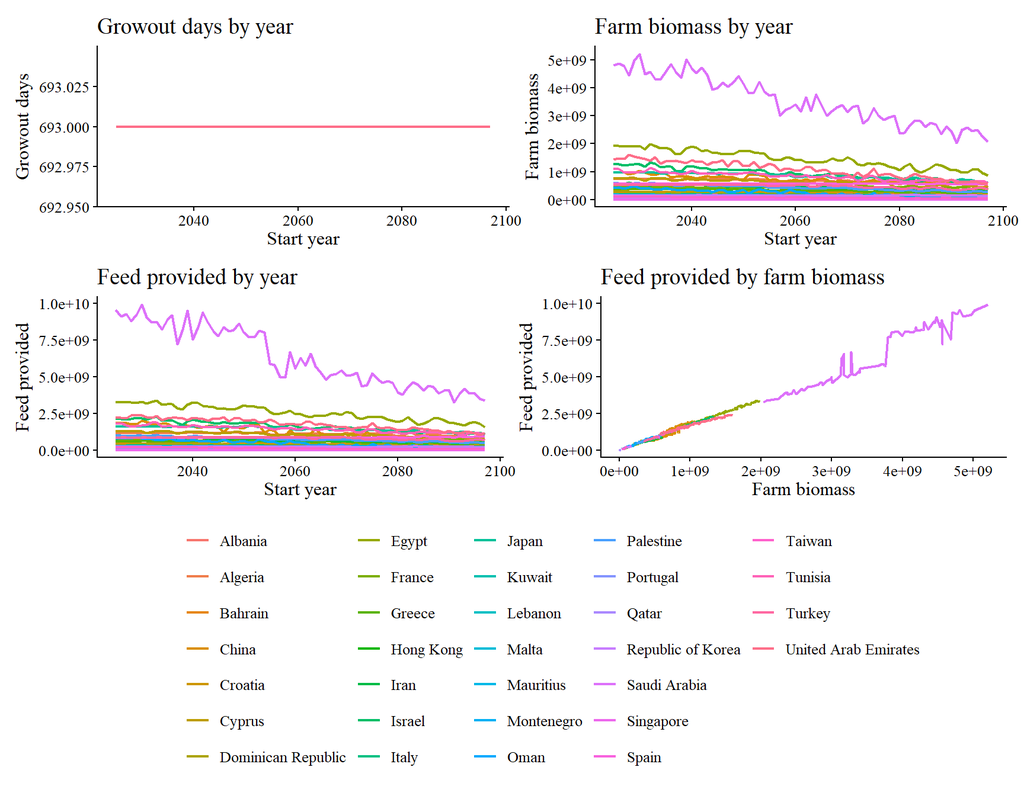

```r
option_2_changes <- file.path(data_path, "intermediates", "option_2_changes.qs") %>%
  qd_read() %>%
  mutate(country = as.factor(country))

p1 <- ggplot(option_2_changes, aes(x = start_year, y = days_to_harvest, colour = country)) +
  geom_line(linewidth = 0.75) +
  labs(x = "Start year", y = "Growout days", title = "Growout days by year") +
  prettyplot()

p2 <- ggplot(option_2_changes, aes(x = start_year, y = farm_biomass, colour = country)) +
  geom_line(linewidth = 0.75) +
  labs(x = "Start year", y = "Farm biomass", title = "Farm biomass by year") +
  prettyplot()

p3 <- ggplot(option_2_changes, aes(x = start_year, y = farm_food_prov, colour = country)) +
  geom_line(linewidth = 0.75) +
  labs(x = "Start year", y = "Feed provided", title = "Feed provided by year") +
  prettyplot()

p4 <- ggplot(option_2_changes, aes(x = farm_biomass, y = farm_food_prov, colour = country)) +
  geom_line(linewidth = 0.75) +
  labs(x = "Farm biomass", y = "Feed provided", title = "Feed provided by farm biomass") +
  prettyplot()

(p1 + p2) / (p3 + p4) +
  plot_layout(guides = "collect") &
  theme(legend.position = "bottom")
```

**Run the model with all species parameters and target harvested biomass fixed through time, with population allowed to change to adapt with the climate**

```r
# ftp <- farm_temps_pops[[1]]
option_3_changes <- map_dfr(farm_temps_pops, function (ftp) {
  # start_year <- (2025:2098)[1]
  map_dfr(2025:2097, function(start_year) {
    ftpy <- ftp %>%
      filter(year %in% c(start_year, start_year + 1)) %>%
      mutate(
        doy = as.integer(format(date, "%j")),
        doy = case_when(
          year == start_year ~ doy,
          leap_year(date) ~ doy + 366,
          T ~ doy + 365
        )
      ) %>%
      filter(doy >= doy_start)
    ftpy <- ftpy[1:species_params["gd"], ] # required because some years are leap years, so the end date will be a little different
    times <- c(t_start = unique(ftpy$doy_start), t_end = (unique(ftpy$doy_start) + nrow(ftpy) - 1), dt = 1L)

    results_full <- farm_growth_full(
      species_params = species_params,
      feed_params = feed_params,
      water_temp = ftpy$sst,
      times = times,
      use_MC_population = F
    )
    results_consolidate <- consolidate_farm(results_full)

    # Adapt population to absorb the changes in individual size
    harvest_ind_weight <- last(results_consolidate[["stats"]][["weight"]][,1])
    target_biomass <- unique(ftpy$prod_perfarm) %>% set_units("t") %>% set_units("g") %>% drop_units()
    N_pop_adj <- generate_pop(
      harvest_n = target_biomass/harvest_ind_weight,
      mort = species_params["mortmyt"],
      times = times
    )

    results_farm <- scale_farm_population(
      consolidated = results_consolidate,
      N_pop = N_pop_adj
    )

    data.frame(
      start_year = start_year,
      population = target_biomass/harvest_ind_weight,
      farm_biomass = last(results_farm[["stats"]][["weight_scaled"]][,1]),
      farm_food_prov = sum(results_farm[["stats"]][["food_prov_scaled"]][,1], na.rm = T)
    )
  }) %>%
    mutate(
      country = unique(ftp$country),
      farm_ID = unique(ftp$farm_ID)
    )
},
.progress = T
)

qd_save(
  option_3_changes,
  file.path(data_path, "intermediates", "option_3_changes.qs")
)
```

**Look at option 3 outcomes**

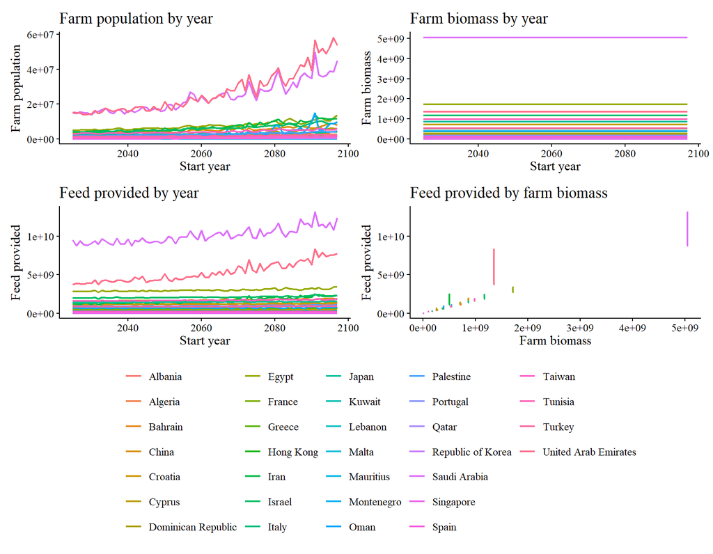

Figure 3: Outputs from Option 3 above - species parameters and target harvested biomass are kept constant through time, and population is changed to absorb the difference. Results show a single farm within each country.

```r
option_3_changes <- file.path(data_path, "intermediates", "option_3_changes.qs") %>%
  qd_read() %>%
  mutate(country = as.factor(country))

p1 <- ggplot(option_3_changes, aes(x = start_year, y = population, colour = country)) +
  geom_line(linewidth = 0.75) +
  labs(x = "Start year", y = "Farm population", title = "Farm population by year") +
  prettyplot()

p2 <- ggplot(option_3_changes, aes(x = start_year, y = farm_biomass, colour = country)) +
  geom_line(linewidth = 0.75) +
  labs(x = "Start year", y = "Farm biomass", title = "Farm biomass by year") +
  prettyplot()

p3 <- ggplot(option_3_changes, aes(x = start_year, y = farm_food_prov, colour = country)) +
  geom_line(linewidth = 0.75) +
  labs(x = "Start year", y = "Feed provided", title = "Feed provided by year") +
  prettyplot()

p4 <- ggplot(option_3_changes, aes(x = farm_biomass, y = farm_food_prov, colour = country)) +
  geom_line(linewidth = 0.75) +
  labs(x = "Farm biomass", y = "Feed provided", title = "Feed provided by farm biomass") +
  prettyplot()

(p1 + p2) / (p3 + p4) +
  plot_layout(guides = "collect") &
  theme(legend.position = "bottom")
```

← Previous: Extracting future temperatures

Next: Home →